# asn_jessica

Jessica

2023-10-11

# PART 1 OF ASSIGNMENT

Import the dataset and store into medicalcostdata

```r
MedicalCostData = read.csv("MedicalCost.csv")
```

Display the first few elements

```r
head(MedicalCostData)
```

```
##   age    sex    bmi children smoker    region   charges
## 1  19 female 27.900        0    yes southwest 16884.924
## 2  18   male 33.770        1     no southeast  1725.552
## 3  28   male 33.000        3     no southeast  4449.462
## 4  33   male 22.705        0     no northwest 21984.471
## 5  32   male 28.880        0     no northwest  3866.855
## 6  31 female 25.740        0     no southeast  3756.622
```

Make a scatterplot of charges against age; do you observe a positive/negative correlation, or no relationship at all?

I observe a positive correlation between age and charges; meaning as age increases, the charges increases too.

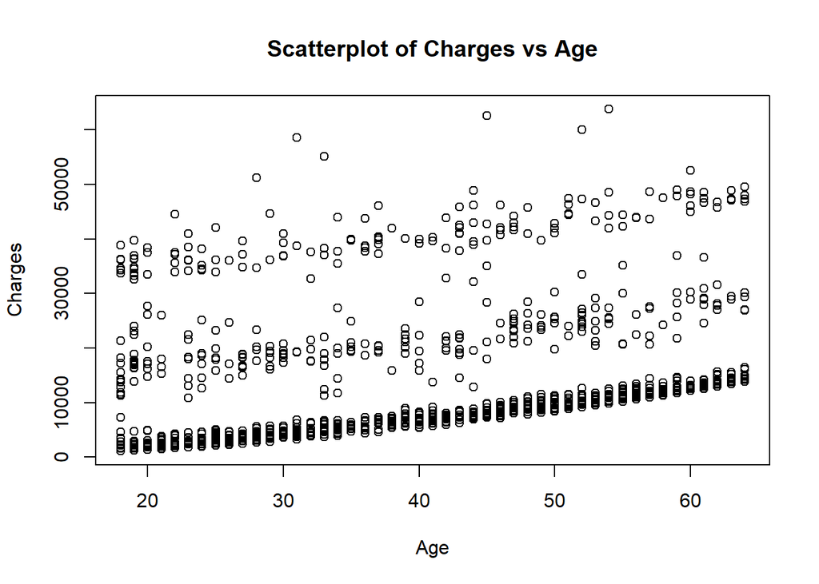

```r
plot(MedicalCostData$age, MedicalCostData$charges, xlab = "Age", ylab = "Charges", main = "Scatterplot of Charges vs Age")
```

Make a scatterplot of charges against bmi; do you observe a positive/negative correlation, or no relationship at all?

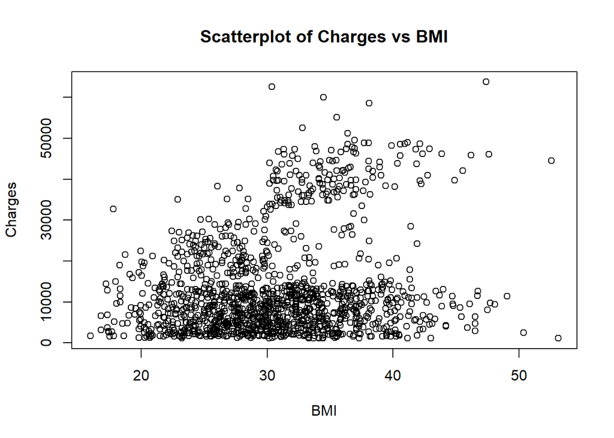

```r
plot(MedicalCostData$bmi, MedicalCostData$charges, xlab = "BMI", ylab = "Charges", main = "Scatterplot of Charges vs BMI")
```

Using the command factor() transform the variable sex into a binary coding (1 for female, 0 for male). Hint: you have levels=c(“male”, “female”)

```r
sex = factor(MedicalCostData$sex, levels = c("male", "female"))
MedicalCostData$sex = as.numeric(sex) - 1
head(MedicalCostData)
```

```
##   age sex    bmi children smoker    region   charges
## 1  19   1 27.900        0    yes southwest 16884.924
## 2  18   0 33.770        1     no southeast  1725.552
## 3  28   0 33.000        3     no southeast  4449.462
## 4  33   0 22.705        0     no northwest 21984.471
## 5  32   0 28.880        0     no northwest  3866.855
## 6  31   1 25.740        0     no southeast  3756.622
```

Similarly, transform the variable smoker into a binary coding (1 for yes). Hint: you have levels=c(“no”, “yes”)

```r
smoker = factor(MedicalCostData$smoker, levels = c("no", "yes"))
MedicalCostData$smoker = as.numeric(smoker) - 1
head(MedicalCostData)
```

```
##   age sex    bmi children smoker    region   charges
## 1  19   1 27.900        0      1 southwest 16884.924
## 2  18   0 33.770        1      0 southeast  1725.552
## 3  28   0 33.000        3      0 southeast  4449.462
## 4  33   0 22.705        0      0 northwest 21984.471
## 5  32   0 28.880        0      0 northwest  3866.855
## 6  31   1 25.740        0      0 southeast  3756.622
```

Using one of the methods explained on https://stackoverflow.com/questions/6286313/remove-an-entire-column-from-a-data-frame-in-rLinks to an external site. remove the variable region from the data frame.

```r
MedicalCostData$region <- NULL
head(MedicalCostData)
```

```
##   age sex    bmi children smoker   charges
## 1  19   1 27.900        0      1 16884.924
## 2  18   0 33.770        1      0  1725.552
## 3  28   0 33.000        3      0  4449.462
## 4  33   0 22.705        0      0 21984.471
## 5  32   0 28.880        0      0  3866.855
## 6  31   1 25.740        0      0  3756.622
```

Try obtaining the correlations between all the variables in the dataframe using cor(MedicalCostData[ , ])

```r
correlations <- cor(MedicalCostData)
print(correlations)
```

```
##                  age         sex          bmi    children       smoker
## age       1.00000000  0.02085587  0.109271882  0.04246900 -0.025018752
## sex       0.02085587  1.00000000 -0.046371151 -0.01716298 -0.076184817
## bmi       0.10927188 -0.04637115  1.000000000  0.01275890  0.003750426
## children  0.04246900 -0.01716298  0.012758901  1.00000000  0.007673120
## smoker   -0.02501875 -0.07618482  0.003750426  0.00767312  1.000000000
## charges   0.29900819 -0.05729206  0.198340969  0.06799823  0.787251430
##              charges
## age       0.29900819
## sex      -0.05729206
## bmi       0.19834097
## children  0.06799823
## smoker    0.78725143
## charges   1.00000000
```

What predictors have the largest and the smallest correlations with charges in terms of absolute values? How would you interpret that (intuition only)?

Largest Correlation: “smoker” has the largest absolute correlation with “charges,” with a correlation coefficient of approximately 0.787. This means that smoking status is strongly positively correlated with higher insurance charges. The intuition here is that individuals who smoke tend to have significantly higher health insurance charges compared to non-smokers. Smoking is a major factor influencing insurance costs.

Smallest Correlation: “sex” has the smallest absolute correlation with “charges,” with a correlation coefficient of approximately 0.057. This suggests that an individual’s sex has a weak relationship with insurance charges. In other words, being male or female does not have a strong impact on insurance charges. Gender does not play a significant role in determining insurance costs in this dataset.

# PART 2 OF ASSIGNMENT

15. Run a regression to predict charges using all the available variables as predictors.

```r
model <- lm(charges ~ ., data = MedicalCostData)
```

16. Are there any statistically insignificant predictors in the regression?

```r
summary(model)
```

```
##
## Call:
## lm(formula = charges ~ ., data = MedicalCostData)
##
## Residuals:
##      Min       1Q   Median       3Q      Max
## -11837.2  -2916.7   -994.2   1375.3  29565.5
##
## Coefficients:
##              Estimate Std. Error t value Pr(>|t|)
## (Intercept) -12181.10     963.90 -12.637  < 2e-16 ***
## age            257.73      11.90  21.651  < 2e-16 ***
## sex            128.64     333.36   0.386 0.699641
## bmi            322.36      27.42  11.757  < 2e-16 ***
## children       474.41     137.86   3.441 0.000597 ***
## smoker       23823.39     412.52  57.750  < 2e-16 ***
## ---
## Signif. codes:  0 '***' 0.001 '**' 0.01 '*' 0.05 '.' 0.1 ' ' 1
##
## Residual standard error: 6070 on 1332 degrees of freedom
## Multiple R-squared:  0.7497, Adjusted R-squared:  0.7488
## F-statistic:   798 on 5 and 1332 DF,  p-value: < 2.2e-16
```

17. Repeat the regression without the insignificant predictor(s). Now, what predictor has the largest impact on charges?

In the regression output, the “sex” variable is statistically insignificant. You can determine this by looking at the p-value associated with the coefficient for “sex” in the regression summary. The p-value for “sex” is 0.699641, which is much higher than the typical significance level of 0.05. Therefore, you can conclude that the “sex” variable is not a statistically significant predictor of charges in this regression model.

The other variables, including “age,” “bmi,” “children,” and “smoker,” have p-values less than 0.05, indicating that they are statistically significant predictors of charges in this model.

```r
model_no_sex <- lm(charges ~ age + bmi + children + smoker, data = MedicalCostData)
summary(model_no_sex)
```

```
##
## Call:
## lm(formula = charges ~ age + bmi + children + smoker, data = MedicalCostData)
##
## Residuals:
##      Min       1Q   Median       3Q      Max
## -11897.9  -2920.8   -986.6   1392.2  29509.6
##
## Coefficients:
##              Estimate Std. Error t value Pr(>|t|)
## (Intercept) -12102.77     941.98 -12.848  < 2e-16 ***
## age            257.85      11.90  21.675  < 2e-16 ***
## bmi            321.85      27.38  11.756  < 2e-16 ***
## children       473.50     137.79   3.436 0.000608 ***
## smoker       23811.40     411.22  57.904  < 2e-16 ***
## ---
## Signif. codes:  0 '***' 0.001 '**' 0.01 '*' 0.05 '.' 0.1 ' ' 1
##
## Residual standard error: 6068 on 1333 degrees of freedom
## Multiple R-squared:  0.7497, Adjusted R-squared:  0.7489
## F-statistic: 998.1 on 4 and 1333 DF,  p-value: < 2.2e-16
```

18. Comment on the R-squared and the adjusted R-squared of the regression model without the insignificant predictor (two sentences). In the regression model without the insignificant predictor “sex,” the R-squared value is approximately 0.7497, which indicates that the model explains about 74.97% of the variance in the charges. The adjusted R-squared value is approximately 0.7489, and it is very close to the R-squared value, suggesting that the model remains a good fit even after removing the insignificant predictor.
19. Take a sample size of 80% from the dataset and name it TrainingSet (keep the other 20% of the data under TestingSet).

```r
set.seed(123)  # for reproducibility
sample_index = sample(seq_len(nrow(MedicalCostData)), size = 0.8 * nrow(MedicalCostData))
TrainingSet = MedicalCostData[sample_index, ]
TestingSet = MedicalCostData[-sample_index, ]
```

20. Re-run the regression model (without the insignificant predictor) on the training set (i.e., train your model).

```r
model_no_sex_train <- lm(charges ~ age + bmi + children + smoker, data = TrainingSet)
summary(model_no_sex_train)
```

```
##
## Call:
## lm(formula = charges ~ age + bmi + children + smoker, data = TrainingSet)
##
## Residuals:
##      Min       1Q   Median       3Q      Max
## -11858.4  -2937.3   -936.3   1585.6  29425.9
##
## Coefficients:
##              Estimate Std. Error t value Pr(>|t|)
## (Intercept) -12351.07    1080.68 -11.429  < 2e-16 ***
## age            244.00      13.64  17.893  < 2e-16 ***
## bmi            341.76      31.10  10.990  < 2e-16 ***
## children       555.40     156.16   3.557 0.000392 ***
## smoker       24162.30     458.29  52.723  < 2e-16 ***
## ---
## Signif. codes:  0 '***' 0.001 '**' 0.01 '*' 0.05 '.' 0.1 ' ' 1
##
## Residual standard error: 6145 on 1065 degrees of freedom
## Multiple R-squared:  0.7523, Adjusted R-squared:  0.7514
## F-statistic: 808.8 on 4 and 1065 DF,  p-value: < 2.2e-16
```

21. Using the trained model, make predictions for the testing set.

```r
predictions_test = predict(model_no_sex_train, newdata = TestingSet)
```

22. Calculate the Root Mean Squared Error (RMSE). Do you think it’s high or low?

```r
rmse <- sqrt(mean((TestingSet$charges - predictions_test)^2))
cat("The RMSE is: ", rmse)
```

```
## The RMSE is:  5783.394
```

```r
charge_range <- range(MedicalCostData$charges)
cat("Range of charges: ", charge_range[1], " to ", charge_range[2])
```

```
## Range of charges:  1121.874  to  63770.43
```

the RMSE of 5783.394 is a significant portion of the range of charges. When the RMSE is a large fraction of the range of the target variable, it typically indicates that the model’s predictions have a substantial level of error compared to the variability in the actual data.

23. Find the definition of Mean Absolute Percentage Error (MAPE) from web and include it in your submission.

The Mean Absolute Percentage Error (MAPE) is a commonly used metric for measuring the accuracy of a predictive model, particularly in forecasting and time series analysis. MAPE quantifies the percentage difference between predicted and actual values, making it easy to interpret in terms of relative accuracy.

24. Calculate the MAPE (using a package or a function you define yourself). What is the main advantage of MAPE over RMSE?

```r
mape <- function(actual, predicted) {
  if (length(actual) != length(predicted)) {
    stop("Lengths of actual and predicted vectors must be the same.")
  }

  N <- length(actual)
  mape_value <- sum(abs((predicted - actual) / actual)) / N * 100
  return(mape_value)
}


actual_values <- TestingSet$charges
predicted_values <- predictions_test
mape_score <- mape(actual_values, predicted_values)
cat("MAPE:", mape_score, "%")
```

```
## MAPE: 45.84003 %
```

The primary advantage of Mean Absolute Percentage Error (MAPE) over Root Mean Squared Error (RMSE) is its percentage-based nature, making it easily interpretable and suitable for comparing models with different scales. (For example, let’s say you’re comparing the prediction accuracy of two different models A and B, for of Product X and Product Y, respectively. Product X is an expensive luxury item with prices ranging from 1,000 to 10,000 dollars, while Product Y is an everyday household item with prices ranging from 10 to 100 dollars.)